# Rapport BIO500

Béatrice Dupuis, Félix-Olivier Dufour, Hugo Morin-Brassard, Rosalie Gagnon  
2023-04-21

## Introduction

Les réseaux de collaboration écologique sont complexes et comportent plusieurs niveaux d’interactions entre les organismes, ce qui peut rapidement les rendre difficiles à comprendre. Pour se familiariser avec ce concept, le cours de Méthodes en écologie computationnelle (BIO500) offre la possibilité de recréer un réseau écologique à partir des collaborations des étudiants du cours. Pour ce faire, différentes informations ont été compilées tout d’abord par rapport à l’étudiant lui-même, ensuite par rapport aux cours suivis par celui-ci puis finalement avec qui cet étudiant à collaborer. Avec ces informations en main, il sera possible d’établir un réseau de collaborations entre tous les étudiants et de le comparer à un réseau d’interactions au sein d’un écosystèmes naturels. Pour se faire, nous avons déterminer certaines questions auxquelles nous essaieront de répondre. Les questions sur lesquelles ce rapport ce penchera sont les suivantes : est-ce que les élèves qui proviennent des mêmes régions administratives ont plus tendances à travailler ensemble? On voudrait également savoir si les élèves qui ont commencé le bac la même année auront tendance à plus collaborer entre eux.

## Méthodes

Les données pour la réalisation de ce projet ont été acquise dans la population d’étudiant du cours Méthodes en écologie computationnelle (BIO500) à l’université de Sherbrooke (N = 38) au cours de la session d’hiver 2023. Un document Excel a été rempli par chaque étudiant pour enregistrer leurs informations personnelles, les cours qu’ils ont suivis tout au long de leur parcours, ainsi que les collaborations effectuées dans ces différents cours. Une collaboration a été défini dans ce projet comme tout événements de coopération entre deux étudiants dans le cadre de travaux scolaires. Par exemple, dans ce présent projet Béatrice a collaboré avec 3 personnes, soit Félix-Olivier, Hugo et Rosalie. Par la suite, étant donné la présence de doublon et d’erreurs de saisies, nous avons élaboré un algorithme spécifique à nos données pour le nettoyage de celles-ci.Ces données nettoyées ont ensuite été injecté dans une base de données SQL qui nous a permis de réaliser nos analyses. Le nettoyage des données et les analyses ont été effectué à l’aide du logiciel R (R Core Team, 2023). Pour obtenir plus d’informations sur le nettoyage de données, l’analyse de données ou les données en général, vous pouvez consulter le dépôt de travail Github suivant https://github.com/HugoM-B/Bio500.

## Résultats

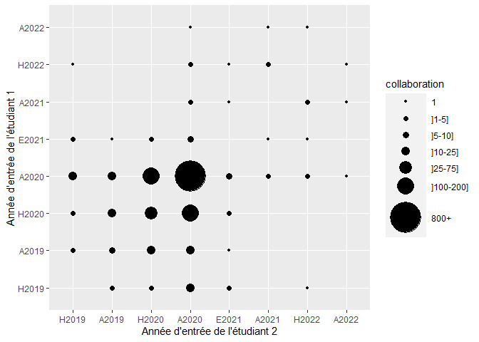

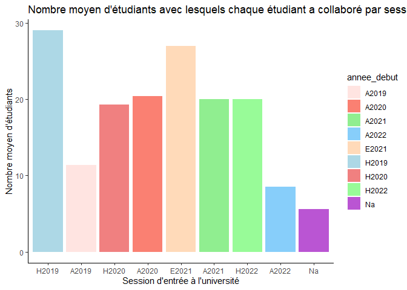

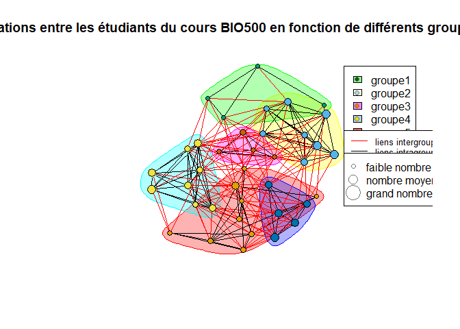

```r
#read data
data<-tar_read(list_requete)
collab_pair_region<-data[[4]]
data1<-tar_read(list_table_apres_nettoyage)
etudiant<-data1[[1]]
 #Créer la liste des regions administratives et inclure l'ensemble des valeurs de distance regionnale dans une matrice (voir methodologie pour l'origine des valeurs)
liste<-unique(etudiant$region_administrative)
connect<-c(1,2,2,4,3,3,4,3,3,4,3,3,4,2,4,0,3,2,1,2,3,2,2,4,2,3,4,3,3,3,2,4,0,3,2,2,1,3,2,2,3,3,4,5,2,2,3,1,3,0,4,4,3,3,1,2,3,3,2,3,3,4,3,3,3,4,0,3,3,2,2,2,1,2,2,2,3,4,3,2,2,2,3,0,3,3,2,2,3,2,1,3,3,4,5,2,2,3,2,2,0,4,4,4,3,3,2,3,1,3,4,5,3,2,2,3,3,0,4,3,2,3,2,2,3,3,1,2,3,4,3,3,3,4,0,2,3,3,4,3,3,4,4,2,1,2,5,4,4,4,5,0,1,4,4,5,3,4,5,5,3,2,1,6,5,5,5,6,0,2,3,3,2,4,3,2,3,4,5,6,1,2,4,2,2,0,5,3,3,2,3,2,2,2,3,4,5,2,1,3,2,2,0,4,4,3,3,3,2,3,2,3,4,5,4,3,1,3,4,0,4,2,2,1,3,2,2,3,3,4,5,2,2,3,1,3,0,4,4,4,3,4,3,2,3,4,5,6,2,2,4,3,1,0,5,0,0,0,0,0,0,0,0,0,0,0,0,0,0,0,0,0,3,3,4,3,3,4,4,2,1,2,5,4,4,4,5,0,1)
myMatregion <- matrix(connect, length(liste), length(liste), dimnames = list(liste, liste))

#Calcule de la somme de collaborations par region
collabpar_region<-collab_pair_region[,c(1:2)]
nomreg<-unique(collabpar_region$region1)
totalcollab_par_reg<-matrix(ncol = 2,nrow = length(nomreg))
colnames(totalcollab_par_reg)<-c("region1","nb_collabo")
q<-1
for (t in 1:length(nomreg)) {
  collab_t<-subset(collabpar_region,collabpar_region$region1==nomreg[t])
  totalcollab_par_reg[q,1]<-nomreg[t]
  totalcollab_par_reg[q,2]<-sum(collab_t$nb_collaborations)
  q<-q+1
}
#Ajout du nombre de collaboration par region au tableau présentant les collaboration entr pair de region selon la region 1
indices <- which(myMatregion != 0, arr.ind = TRUE)
tableau_distances <- data.frame(region1 = rownames(myMatregion)[indices[, 1]], region2 = colnames(myMatregion)[indices[, 2]], distance = myMatregion[indices])
tableau_final <- merge(collab_pair_region, tableau_distances, by = c("region1", "region2"))
# Fusionner les valeurs propres avec le tableau final
tableau_final <- merge(tableau_final, totalcollab_par_reg, by = "region1")

#Ajout d'une colonne de collaboration pondéré selon la region
as.data.frame(tableau_final)
```

```
##                           region1                       region2
## 1           abitibi_temiscamingue              centre_du_quebec
## 2           abitibi_temiscamingue                        estrie
## 3           abitibi_temiscamingue                   laurentides
## 4           abitibi_temiscamingue                    monteregie
## 5               bas_saint_laurent              centre_du_quebec
## 6               bas_saint_laurent                        estrie
## 7               bas_saint_laurent                    lanaudiere
## 8               bas_saint_laurent                   laurentides
## 9               bas_saint_laurent                      mauricie
## 10              bas_saint_laurent                    monteregie
## 11              bas_saint_laurent                      montreal
## 12              bas_saint_laurent       saguenay_lac_saint_jean
## 13               centre_du_quebec         abitibi_temiscamingue
## 14               centre_du_quebec             bas_saint_laurent
```

[output cut: 237 more lines]

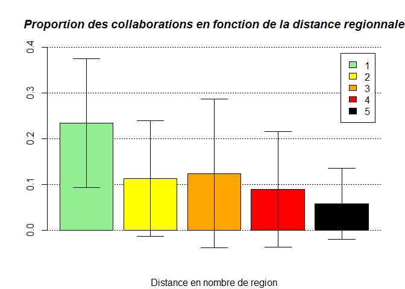

```r
tableau_final[,3]<-as.numeric(tableau_final[,3])
tableau_final[,5]<-as.numeric(tableau_final[,5])
tableau_final$proportion<-tableau_final[,3]/tableau_final[,5]
#Moyenne et écart-type sur cette collaboration pondéré
Donnee_vis<-matrix(nrow = 5, ncol = 3)
colnames(Donnee_vis)<-c("distance","moyenne","sd")
e<-c(1,2,3,4,5)
q<-1
Donnee_vis[,1]<-e
for (p in 1:5) {
  distance<-subset(tableau_final, tableau_final$distance==e[p])
  Donnee_vis[q,2]<-mean(distance$proportion)
  Donnee_vis[q,3]<-sd(distance$proportion)
  q<-q+1
}
install.packages("gplots")
library(gplots)
ecart_sup<-Donnee_vis[,2]+Donnee_vis[,3]
ecart_inf<-Donnee_vis[,2]-Donnee_vis[,3]
mp <- barplot2(Donnee_vis[,2], beside = TRUE,
               col = c("lightgreen","yellow",
                       "orange", "red","black"),
               legend = Donnee_vis[,1], ylim = c(0,0.4),
               main = "Proportion des collaborations en fonction de la distance regionnale", font.main = 4,
               sub = "Distance en nombre de region",
               cex.names = 1.5, plot.ci = TRUE, ci.l = ecart_inf, ci.u = ecart_sup,
               plot.grid = TRUE)
```